# Multivariate Relationships with Absolute Deviation (w/o PC)

MPT Reanalysis Project (code and text current document: Henrik Singmann)

Results from: 2022-07-01

# Overview

This document provides an overview of the multivariate relationships of all moderators with the absolute parameter deviation. As in the analysis of the univariate relationships we focus on two reference methods, the complete pooling MLE method and the latent-trait partial pooling method.

# Correlations and Multicollinearity (all pairs)

When looking at the multivariate relationships, we need to consider the degree of multicollinearity that could be present in the data. The following plot shows the distribution of correlations across all pairs of moderators in the data across each pair of one of the reference methods with each other method. More specifically, each data point underlying the depiction in each row of the figure is the correlation for these two moderators for one pair of methods where in each case at least one of the methods in each pair is one of the two reference methods. The figure then depicts the median of these distribution as a solid point and the error bars depict the minimum and the maximum.

This figure shows that for several of the pairs there is substantial correlation between .25 and .5, but not really higher.

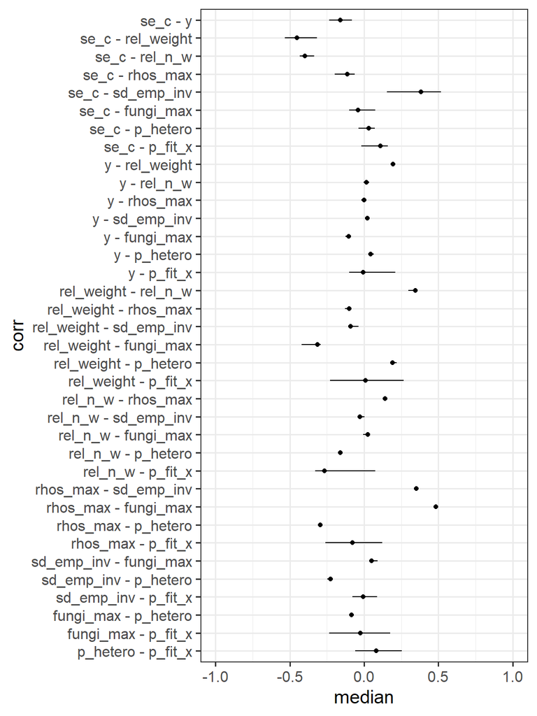

The following table lists some summary statistics of the correlation distribution ordered by largest absolute minimum correlation:

```
## # A tibble: 36 x 6
##    corr                     min    max median   mean     sd
##    <fct>                  <dbl>  <dbl>  <dbl>  <dbl>  <dbl>
##  1 se_c - rel_weight      -0.53 -0.32  -0.45  -0.45  0.059
##  2 rhos_max - fungi_max    0.48  0.49   0.48   0.48  0.0040
##  3 se_c - rel_n_w         -0.43 -0.33  -0.40  -0.40  0.027
##  4 rel_weight - fungi_max -0.42 -0.29  -0.31  -0.33  0.038
##  5 rhos_max - sd_emp_inv   0.35  0.35   0.35   0.35  0.0029
##  6 rel_n_w - p_fit_x      -0.33  0.074 -0.27  -0.19  0.15
##  7 rhos_max - p_hetero    -0.31 -0.29  -0.29  -0.30  0.0049
##  8 rel_weight - rel_n_w    0.30  0.36   0.35   0.34  0.018
##  9 rhos_max - p_fit_x     -0.26  0.12  -0.079 -0.078 0.11
## 10 sd_emp_inv - p_hetero  -0.25 -0.23  -0.23  -0.23  0.0078
## # ... with 26 more rows
```

The following table lists the same correlation distribution summary statistics ordered by largest absolute maximum correlation:

```
## # A tibble: 36 x 6
##    corr                      min   max  median   mean     sd
##    <fct>                   <dbl> <dbl>   <dbl>  <dbl>  <dbl>
##  1 se_c - sd_emp_inv       0.15   0.52  0.38    0.36  0.12
##  2 rhos_max - fungi_max    0.48   0.49  0.48    0.48  0.0040
##  3 rel_weight - rel_n_w    0.30   0.36  0.35    0.34  0.018
##  4 rhos_max - sd_emp_inv   0.35   0.35  0.35    0.35  0.0029
##  5 se_c - rel_n_w         -0.43  -0.33 -0.40   -0.40  0.027
##  6 se_c - rel_weight      -0.53  -0.32 -0.45   -0.45  0.059
##  7 rel_weight - fungi_max -0.42  -0.29 -0.31   -0.33  0.038
##  8 rhos_max - p_hetero    -0.31  -0.29 -0.29   -0.30  0.0049
##  9 rel_weight - p_fit_x   -0.23   0.27  0.0094  0.031 0.15
## 10 p_hetero - p_fit_x     -0.060  0.26  0.081   0.11  0.11
## # ... with 26 more rows
```

The following table lists the same correlation distribution summary statistics ordered by largest absolute median:

```
## # A tibble: 36 x 6
##    corr                       min    max median   mean     sd
##    <fct>                    <dbl>  <dbl>  <dbl>  <dbl>  <dbl>
##  1 rhos_max - fungi_max     0.48   0.49   0.48   0.48  0.0040
##  2 se_c - rel_weight       -0.53  -0.32  -0.45  -0.45  0.059
##  3 se_c - rel_n_w          -0.43  -0.33  -0.40  -0.40  0.027
##  4 se_c - sd_emp_inv        0.15   0.52   0.38   0.36  0.12
##  5 rhos_max - sd_emp_inv    0.35   0.35   0.35   0.35  0.0029
##  6 rel_weight - rel_n_w     0.30   0.36   0.35   0.34  0.018
##  7 rel_weight - fungi_max  -0.42  -0.29  -0.31  -0.33  0.038
##  8 rhos_max - p_hetero     -0.31  -0.29  -0.29  -0.30  0.0049
##  9 rel_n_w - p_fit_x       -0.33   0.074 -0.27  -0.19  0.15
## 10 sd_emp_inv - p_hetero   -0.25  -0.23  -0.23  -0.23  0.0078
## 11 y - rel_weight           0.19   0.20   0.19   0.19  0.0047
## 12 rel_weight - p_hetero    0.19   0.22   0.19   0.20  0.012
## 13 rel_n_w - p_hetero      -0.17  -0.15  -0.16  -0.16  0.0063
## 14 se_c - y                -0.24  -0.080 -0.16  -0.15  0.050
## 15 rel_n_w - rhos_max       0.13   0.15   0.14   0.14  0.0044
## 16 se_c - p_fit_x          -0.018  0.16   0.11   0.084 0.063
## 17 se_c - rhos_max         -0.20  -0.063 -0.11  -0.12  0.039
## 18 y - fungi_max           -0.12  -0.089 -0.10  -0.11  0.012
## 19 rel_weight - rhos_max   -0.13  -0.094 -0.099 -0.10  0.010
## 20 rel_weight - sd_emp_inv -0.10  -0.037 -0.092 -0.086 0.020
## # ... with 16 more rows
```

# Correlations and Multicollinearity (selected pairs)

Same as above, but only looking at the selected method pairs reported in the paper.

This figure also shows that for several of the pairs there is substantial correlation between .25 and .5 but not really higher.

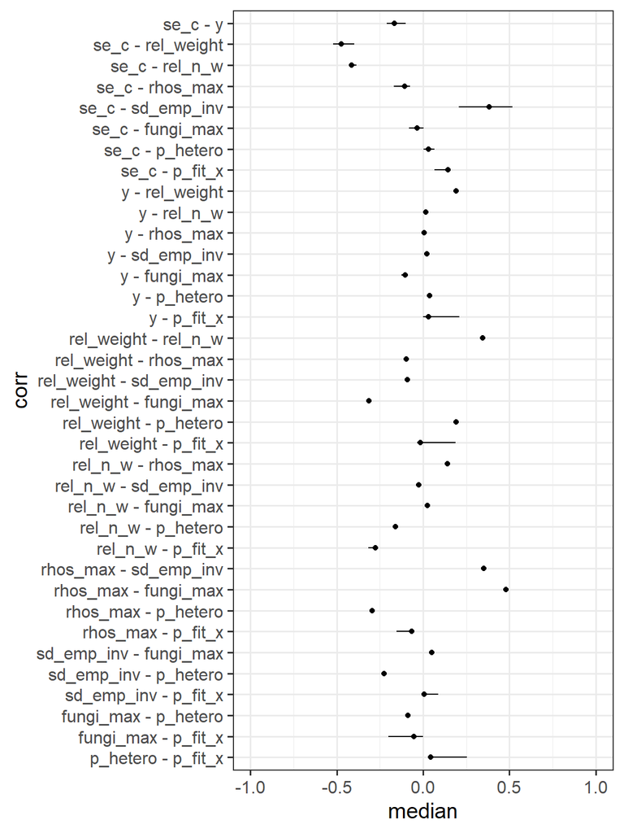

The following table lists the correlation ordered by largest absolute minimum:

```
## # A tibble: 36 x 6
##    corr                     min    max median  mean      sd
##    <fct>                  <dbl>  <dbl>  <dbl> <dbl>   <dbl>
##  1 se_c - rel_weight      -0.52 -0.40   -0.47 -0.46 0.049
##  2 rhos_max - fungi_max    0.48  0.49    0.48  0.48 0.0029
##  3 se_c - rel_n_w         -0.43 -0.39   -0.41 -0.41 0.016
##  4 rhos_max - sd_emp_inv   0.35  0.35    0.35  0.35 0.0013
##  5 rel_weight - rel_n_w    0.34  0.35    0.35  0.34 0.0010
##  6 rel_weight - fungi_max -0.32 -0.31   -0.31 -0.32 0.0020
##  7 rel_n_w - p_fit_x      -0.32 -0.27   -0.28 -0.29 0.025
##  8 rhos_max - p_hetero    -0.29 -0.29   -0.29 -0.29 0.00037
##  9 sd_emp_inv - p_hetero  -0.23 -0.23   -0.23 -0.23 0.00044
## 10 se_c - y               -0.21 -0.099  -0.17 -0.16 0.046
## # ... with 26 more rows
```

The following table lists the correlation ordered by largest absolute maximum:

```
## # A tibble: 36 x 6
##    corr                      min   max median  mean      sd
##    <fct>                   <dbl> <dbl>  <dbl> <dbl>   <dbl>
##  1 se_c - sd_emp_inv       0.21   0.52  0.38   0.37 0.12
##  2 rhos_max - fungi_max    0.48   0.49  0.48   0.48 0.0029
##  3 se_c - rel_weight      -0.52  -0.40 -0.47  -0.46 0.049
##  4 se_c - rel_n_w         -0.43  -0.39 -0.41  -0.41 0.016
##  5 rhos_max - sd_emp_inv   0.35   0.35  0.35   0.35 0.0013
##  6 rel_weight - rel_n_w    0.34   0.35  0.35   0.34 0.0010
##  7 rel_weight - fungi_max -0.32  -0.31 -0.31  -0.32 0.0020
##  8 rhos_max - p_hetero    -0.29  -0.29 -0.29  -0.29 0.00037
##  9 rel_n_w - p_fit_x      -0.32  -0.27 -0.28  -0.29 0.025
## 10 p_hetero - p_fit_x      0.042  0.26  0.046  0.13 0.12
## # ... with 26 more rows
```

The following table lists the correlation ordered by largest absolute median:

```
## # A tibble: 36 x 6
##    corr                       min    max median   mean      sd
##    <fct>                    <dbl>  <dbl>  <dbl>  <dbl>   <dbl>
##  1 rhos_max - fungi_max     0.48   0.49   0.48   0.48  0.0029
##  2 se_c - rel_weight       -0.52  -0.40  -0.47  -0.46  0.049
##  3 se_c - rel_n_w          -0.43  -0.39  -0.41  -0.41  0.016
##  4 se_c - sd_emp_inv        0.21   0.52   0.38   0.37  0.12
##  5 rhos_max - sd_emp_inv    0.35   0.35   0.35   0.35  0.0013
##  6 rel_weight - rel_n_w     0.34   0.35   0.35   0.34  0.0010
##  7 rel_weight - fungi_max  -0.32  -0.31  -0.31  -0.32  0.0020
##  8 rhos_max - p_hetero     -0.29  -0.29  -0.29  -0.29  0.00037
##  9 rel_n_w - p_fit_x       -0.32  -0.27  -0.28  -0.29  0.025
## 10 sd_emp_inv - p_hetero   -0.23  -0.23  -0.23  -0.23  0.00044
## 11 y - rel_weight           0.19   0.19   0.19   0.19  0.0020
## 12 rel_weight - p_hetero    0.19   0.19   0.19   0.19  0.00041
## 13 se_c - y                -0.21  -0.099 -0.17  -0.16  0.046
## 14 rel_n_w - p_hetero      -0.16  -0.16  -0.16  -0.16  0.00072
## 15 se_c - p_fit_x           0.067  0.16   0.14   0.13  0.037
## 16 rel_n_w - rhos_max       0.14   0.14   0.14   0.14  0.00018
## 17 se_c - rhos_max         -0.17  -0.076 -0.11  -0.12  0.035
## 18 y - fungi_max           -0.12  -0.098 -0.10  -0.11  0.011
## 19 rel_weight - rhos_max   -0.10  -0.098 -0.098 -0.099 0.00091
## 20 rel_weight - sd_emp_inv -0.092 -0.090 -0.091 -0.091 0.00075
## # ... with 16 more rows
```

# Multiple Regression

We then consider multiple regression models.

These models have the following numbers of parameters.

```
## # A tibble: 15 x 14
##    cond_label cond_iv_label  mean parameterr mse_c  main inter2  se_y se_y_sd se_y_fungi se_y_sd_fungi best2 best3 best4
##    <fct>      <fct>         <dbl>      <dbl> <dbl> <dbl>  <dbl> <dbl>   <dbl>      <dbl>         <dbl> <dbl> <dbl> <dbl>
##  1 R: CP-MLE  C: CP-Bayes       1         49     2    11     55     4       5          5             6     4     5     6
##  2 R: CP-MLE  C: NP-Bayes       1         46     2    11     55     4       5          5             6     4     5     6
##  3 R: CP-MLE  C: NP-MLE         1         49     2    11     55     4       5          5             6     4     5     6
##  4 R: CP-MLE  C: NP-NPB         1         49     2    11     55     4       5          5             6     4     5     6
##  5 R: CP-MLE  C: NP-PB          1         49     2    11     55     4       5          5             6     4     5     6
##  6 R: CP-MLE  C: PP-B           1         49     2    11     55     4       5          5             6     4     5     6
##  7 R: CP-MLE  C: PP-LT-C        1         49     2    11     55     4       5          5             6     4     5     6
##  8 R: CP-MLE  C: PP-LT-NC       1         49     2    11     55     4       5          5             6     3     5     6
##  9 R: PP-LT-C C: CP-Bayes       1         49     2    11     55     4       5          5             6     3     5     6
## 10 R: PP-LT-C C: NP-Bayes       1         46     2    11     55     4       5          5             6     4     5     6
## 11 R: PP-LT-C C: NP-MLE         1         49     2    11     55     4       5          5             6     4     5     6
## 12 R: PP-LT-C C: NP-NPB         1         49     2    11     55     4       5          5             6     4     5     6
## 13 R: PP-LT-C C: NP-PB          1         49     2    11     55     4       5          5             6     4     5     6
## 14 R: PP-LT-C C: PP-B           1         49     2    11     55     4       5          5             6     4     5     6
## 15 R: PP-LT-C C: PP-LT-NC       1         49     2    11     55     4       5          5             6     3     4     5
```

The following table shows the resulting RMSE for all models.

```
## # A tibble: 15 x 14
##    cond_label cond_iv_label  mean parameterr mse_c  main inter2  se_y se_y_sd se_y_fungi se_y_sd_fungi best2 best3 best4
##    <fct>      <fct>         <dbl>      <dbl> <dbl> <dbl>  <dbl> <dbl>   <dbl>      <dbl>         <dbl> <dbl> <dbl> <dbl>
##  1 R: CP-MLE  C: CP-Bayes   0.070      0.067 0.069 0.067  0.062 0.068   0.068      0.068         0.068 0.068 0.067 0.067
##  2 R: CP-MLE  C: NP-Bayes   0.089      0.069 0.075 0.058  0.048 0.059   0.059      0.059         0.059 0.059 0.059 0.058
##  3 R: CP-MLE  C: NP-MLE     0.050      0.037 0.041 0.037  0.032 0.039   0.039      0.038         0.038 0.039 0.038 0.038
##  4 R: CP-MLE  C: NP-NPB     0.057      0.044 0.047 0.043  0.039 0.045   0.045      0.044         0.044 0.045 0.044 0.043
##  5 R: CP-MLE  C: NP-PB      0.071      0.055 0.057 0.053  0.048 0.055   0.055      0.054         0.054 0.055 0.054 0.054
##  6 R: CP-MLE  C: PP-B       0.035      0.027 0.031 0.027  0.023 0.029   0.029      0.028         0.028 0.029 0.028 0.028
##  7 R: CP-MLE  C: PP-LT-C    0.039      0.032 0.032 0.029  0.026 0.031   0.030      0.030         0.030 0.031 0.030 0.030
##  8 R: CP-MLE  C: PP-LT-NC   0.033      0.025 0.029 0.024  0.021 0.028   0.026      0.028         0.025 0.027 0.026 0.025
##  9 R: PP-LT-C C: CP-Bayes   0.073      0.069 0.072 0.069  0.065 0.071   0.070      0.071         0.070 0.071 0.070 0.070
## 10 R: PP-LT-C C: NP-Bayes   0.081      0.063 0.078 0.060  0.050 0.063   0.063      0.062         0.062 0.063 0.062 0.062
## 11 R: PP-LT-C C: NP-MLE     0.049      0.036 0.044 0.039  0.034 0.041   0.041      0.040         0.040 0.041 0.040 0.040
## 12 R: PP-LT-C C: NP-NPB     0.052      0.043 0.046 0.042  0.038 0.043   0.043      0.043         0.042 0.043 0.043 0.042
## 13 R: PP-LT-C C: NP-PB      0.070      0.056 0.061 0.055  0.050 0.057   0.057      0.056         0.056 0.057 0.056 0.056
## 14 R: PP-LT-C C: PP-B       0.035      0.030 0.033 0.027  0.024 0.031   0.029      0.030         0.028 0.030 0.029 0.028
## 15 R: PP-LT-C C: PP-LT-NC   0.024      0.019 0.020 0.019  0.015 0.020   0.020      0.020         0.020 0.020 0.019 0.019
```

We can also reduce this table to only the comparison methods selected in the paper:

```
## # A tibble: 5 x 14
##   cond_label cond_iv_label  mean parameterr mse_c  main inter2  se_y se_y_sd se_y_fungi se_y_sd_fungi best2 best3 best4
##   <fct>      <fct>         <dbl>      <dbl> <dbl> <dbl>  <dbl> <dbl>   <dbl>      <dbl>         <dbl> <dbl> <dbl> <dbl>
## 1 R: CP-MLE  C: NP-MLE     0.050      0.037 0.041 0.037  0.032 0.039   0.039      0.038         0.038 0.039 0.038 0.038
## 2 R: CP-MLE  C: PP-B       0.035      0.027 0.031 0.027  0.023 0.029   0.029      0.028         0.028 0.029 0.028 0.028
## 3 R: CP-MLE  C: PP-LT-C    0.039      0.032 0.032 0.029  0.026 0.031   0.030      0.030         0.030 0.031 0.030 0.030
## 4 R: PP-LT-C C: NP-MLE     0.049      0.036 0.044 0.039  0.034 0.041   0.041      0.040         0.040 0.041 0.040 0.040
## 5 R: PP-LT-C C: PP-B       0.035      0.030 0.033 0.027  0.024 0.031   0.029      0.030         0.028 0.030 0.029 0.028
```

The results show that the model with all `main` effects usually provides an account that is very similar to the `parameter` model. Even including interaction does not bring too much, although including all adds many parameters.

The following table shows the additional variable in the model with the best two moderators and the two additional predictors in the model with the best three moderators. The table below the parameters in the model with the best four parameters.

```
## # A tibble: 5 x 7
##   cond_label cond_iv_label b2_1       b2_2  b3_1  b3_2       b3_3
##   <fct>      <fct>         <chr>      <chr> <chr> <chr>      <chr>
## 1 R: CP-MLE  C: NP-MLE     se_c       y_c   se_c  y_c        fungis_max
## 2 R: CP-MLE  C: PP-B       se_c       y_c   se_c  y_c        fungis_max
## 3 R: CP-MLE  C: PP-LT-C    se_c       y_c   se_c  sd_emp_inv y_c
## 4 R: PP-LT-C C: NP-MLE     se_c       y_c   se_c  y_c        fungis_max
## 5 R: PP-LT-C C: PP-B       sd_emp_inv y_c   se_c  sd_emp_inv y_c
```

```
## # A tibble: 5 x 6
##   cond_label cond_iv_label b4_1  b4_2       b4_3    b4_4
##   <fct>      <fct>         <chr> <chr>      <chr>   <chr>
## 1 R: CP-MLE  C: NP-MLE     se_c  rel_n_w    y_c     fungis_max
## 2 R: CP-MLE  C: PP-B       se_c  y_c        p_fit_x fungis_max
## 3 R: CP-MLE  C: PP-LT-C    se_c  sd_emp_inv y_c     fungis_max
## 4 R: PP-LT-C C: NP-MLE     se_c  rel_n_w    y_c     fungis_max
## 5 R: PP-LT-C C: PP-B       se_c  sd_emp_inv y_c     fungis_max
```

The following plot shows the coeffcicients for the model with SE, value (linear and quadratic) and SD

```
## # A tibble: 5 x 3
##   term           mean median
##   <fct>         <dbl>  <dbl>
## 1 SD            0.016  0.012
## 2 Value (quad)  0.16   0.14
## 3 Value (lin)  -0.019 -0.015
## 4 SE            0.54   0.52
## 5 Intercept    -0.011 -0.010
```

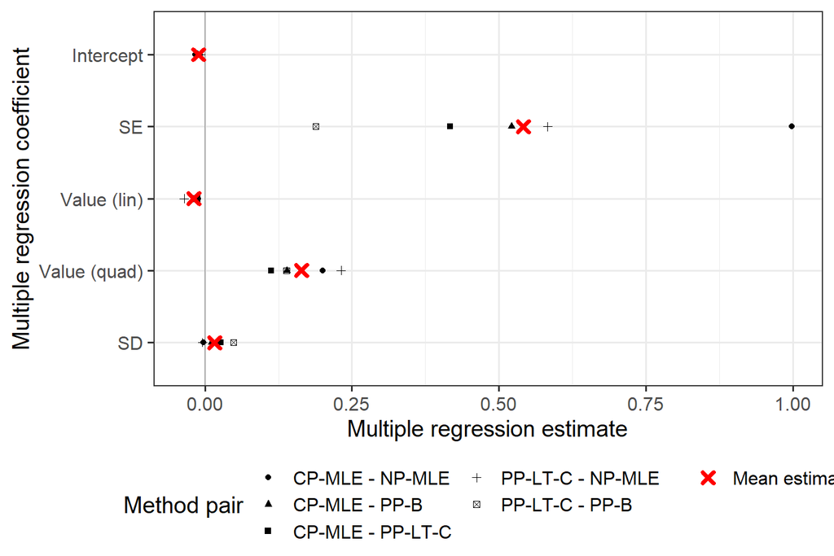

Overview of correlations in model with three best coefficients:

```
## # A tibble: 6 x 6
##   corr                     min     max median   mean     sd
##   <fct>                  <dbl>   <dbl>  <dbl>  <dbl>  <dbl>
## 1 y_c_quad - sd_emp_inv  0.017  0.066   0.019  0.037 0.026
## 2 y_c - sd_emp_inv       0.021  0.024   0.023  0.022 0.0011
## 3 y_c - y_c_quad        -0.14  -0.11   -0.14  -0.13  0.017
## 4 se_c - sd_emp_inv      0.21   0.52    0.38   0.37  0.12
## 5 se_c - y_c_quad       -0.23   0.0062 -0.071 -0.11  0.11
## 6 se_c - y_c            -0.21  -0.099  -0.17  -0.16  0.046
```

# RAMP Model selection

RAMP results for selected method pairs (`rmsec`) and number of coefficients in RAMP model:

```
## # A tibble: 5 x 10
##   cond_label cond_iv_label r      r_c    data                   rmse rmsec main      inter          n
##   <fct>      <fct>         <list> <list> <list>                <dbl> <dbl> <list>    <list>     <dbl>
## 1 R: CP-MLE  C: NP-MLE     <RAMP> <RAMP> <tibble [1,372 x 77]> 0.034 0.034 <int [8]> <chr [12]>    21
## 2 R: CP-MLE  C: PP-B       <RAMP> <RAMP> <tibble [1,357 x 77]> 0.023 0.022 <int [8]> <chr [24]>    33
## 3 R: CP-MLE  C: PP-LT-C    <RAMP> <RAMP> <tibble [1,372 x 77]> 0.027 0.027 <int [7]> <chr [11]>    19
## 4 R: PP-LT-C C: NP-MLE     <RAMP> <RAMP> <tibble [1,372 x 77]> 0.036 0.035 <int [9]> <chr [21]>    31
## 5 R: PP-LT-C C: PP-B       <RAMP> <RAMP> <tibble [1,357 x 77]> 0.023 0.024 <int [7]> <chr [16]>    24
```

Inclusion probability of interactions (only selected method pairs):

```
##                 se_c rhos_max fungis_max y_c sd_emp_inv rel_weight rel_n_w log1p.p_hetero. log1p.p_fit_x.
## se_c               3        1          5   2          3          0       5               3              5
## rhos_max           0        0          2   1          1          0       1               0              1
## fungis_max         0        0          2   3          4          1       3               2              3
## y_c                0        0          0   5          1          1       2               2              2
## sd_emp_inv         0        0          0   0          4          2       1               1              4
## rel_weight         0        0          0   0          0          1       2               0              3
## rel_n_w            0        0          0   0          0          0       0               1              1
## log1p.p_hetero.    0        0          0   0          0          0       0               0              0
## log1p.p_fit_x.     0        0          0   0          0          0       0               0              0
```

```
## [1] 4
```

```
## [1] 3
```

```
## [1] 7
```

```
## [1] 9
```

```
## [1] 13
```

```
## [1] 9
```

```
## [1] 45
```

Inclusion vector of main effects

```
##            se_c        rhos_max      fungis_max             y_c      sd_emp_inv      rel_weight         rel_n_w
##             1.0             0.4             1.0             1.0             1.0             0.8             1.0
## log1p.p_hetero.  log1p.p_fit_x.
##             0.6             1.0
```

RAMP results for all method pairs:

```
## # A tibble: 15 x 9
##    cond_label cond_iv_label r      r_c    data                   rmse rmsec main      inter
##    <fct>      <fct>         <list> <list> <list>                <dbl> <dbl> <list>    <list>
##  1 R: CP-MLE  C: CP-Bayes   <RAMP> <RAMP> <tibble [1,372 x 77]> 0.063 0.063 <int [5]> <chr [7]>
##  2 R: CP-MLE  C: NP-Bayes   <RAMP> <RAMP> <tibble [1,313 x 77]> 0.053 0.053 <int [7]> <chr [14]>
##  3 R: CP-MLE  C: NP-MLE     <RAMP> <RAMP> <tibble [1,372 x 77]> 0.034 0.034 <int [8]> <chr [12]>
##  4 R: CP-MLE  C: NP-NPB     <RAMP> <RAMP> <tibble [1,323 x 77]> 0.040 0.041 <int [5]> <chr [4]>
##  5 R: CP-MLE  C: NP-PB      <RAMP> <RAMP> <tibble [1,335 x 77]> 0.051 0.051 <int [5]> <chr [5]>
##  6 R: CP-MLE  C: PP-B       <RAMP> <RAMP> <tibble [1,357 x 77]> 0.023 0.022 <int [8]> <chr [24]>
##  7 R: CP-MLE  C: PP-LT-C    <RAMP> <RAMP> <tibble [1,372 x 77]> 0.027 0.027 <int [7]> <chr [11]>
##  8 R: CP-MLE  C: PP-LT-NC   <RAMP> <RAMP> <tibble [1,179 x 77]> 0.022 0.022 <int [6]> <chr [9]>
##  9 R: PP-LT-C C: CP-Bayes   <RAMP> <RAMP> <tibble [1,372 x 77]> 0.065 0.067 <int [5]> <chr [3]>
## 10 R: PP-LT-C C: NP-Bayes   <RAMP> <RAMP> <tibble [1,313 x 77]> 0.054 0.054 <int [8]> <chr [13]>
## 11 R: PP-LT-C C: NP-MLE     <RAMP> <RAMP> <tibble [1,372 x 77]> 0.036 0.035 <int [9]> <chr [21]>
## 12 R: PP-LT-C C: NP-NPB     <RAMP> <RAMP> <tibble [1,323 x 77]> 0.039 0.039 <int [5]> <chr [5]>
## 13 R: PP-LT-C C: NP-PB      <RAMP> <RAMP> <tibble [1,335 x 77]> 0.052 0.052 <int [6]> <chr [8]>
## 14 R: PP-LT-C C: PP-B       <RAMP> <RAMP> <tibble [1,357 x 77]> 0.023 0.024 <int [7]> <chr [16]>
## 15 R: PP-LT-C C: PP-LT-NC   <RAMP> <RAMP> <tibble [1,179 x 77]> 0.015 0.015 <int [6]> <chr [7]>
```

Inclusion of interaction for all method pairs:

```
##                 se_c rhos_max fungis_max  y_c sd_emp_inv rel_weight rel_n_w log1p.p_hetero. log1p.p_fit_x.
## se_c             0.4     0.13       0.40 0.53       0.27       0.07    0.87            0.20           0.73
## rhos_max         0.0     0.00       0.20 0.07       0.13       0.00    0.07            0.00           0.07
## fungis_max       0.0     0.00       0.33 0.47       0.27       0.13    0.40            0.13           0.33
## y_c              0.0     0.00       0.00 0.87       0.13       0.20    0.20            0.27           0.27
## sd_emp_inv       0.0     0.00       0.00 0.00       0.27       0.13    0.20            0.07           0.27
## rel_weight       0.0     0.00       0.00 0.00       0.00       0.13    0.20            0.00           0.47
## rel_n_w          0.0     0.00       0.00 0.00       0.00       0.00    0.00            0.07           0.33
## log1p.p_hetero.  0.0     0.00       0.00 0.00       0.00       0.00    0.00            0.00           0.07
## log1p.p_fit_x.   0.0     0.00       0.00 0.00       0.00       0.00    0.00            0.00           0.27
```